# Hypothesis H3 (P2): Time Overrun impacts Customer Trust

Julian Frattini

2025-12-08

This document investigates hypothesis $H_3^{P2}$ (originating from proposition 2):

> If *the project members collectively agreed that if we don’t start implementation now, we would not finish implementation in time*, this causes a *lack of trust between our project team members and stakeholder or customer*.

For analysis, we follow the 3-step framework for statistical causal inference as summarized by Siebert.[^1]

## Modeling

The causal relationships were formalized in the following directed, acyclic graph (see proposition 2 for the full DAG):

```r
dag <- dagify(
  trust.customer ~ team.overrun,

  exposure = "team.overrun",
  outcome = "trust.customer",

  labels = c(
    team.overrun = "team-overrun", trust.customer = "trust-customer"
  ),
  coords = list(
    x = c(team.overrun = 2, trust.customer = 2),
    y = c(team.overrun = 1.5, trust.customer = 0.5)
  )
)

 ggdag_status(dag, use_labels = "label", text = FALSE) +
   theme_dag() +
   theme(legend.position = "bottom") +
   labs(fill = "Variable type", color = "Variable type")
```

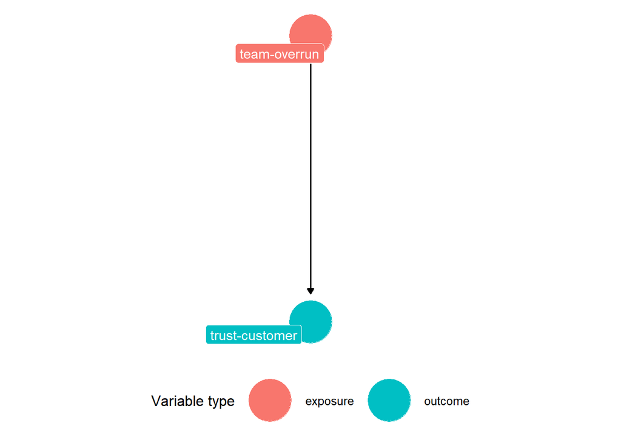

## Identification

Based on the backdoor criterion, we can identify variables to statistically control

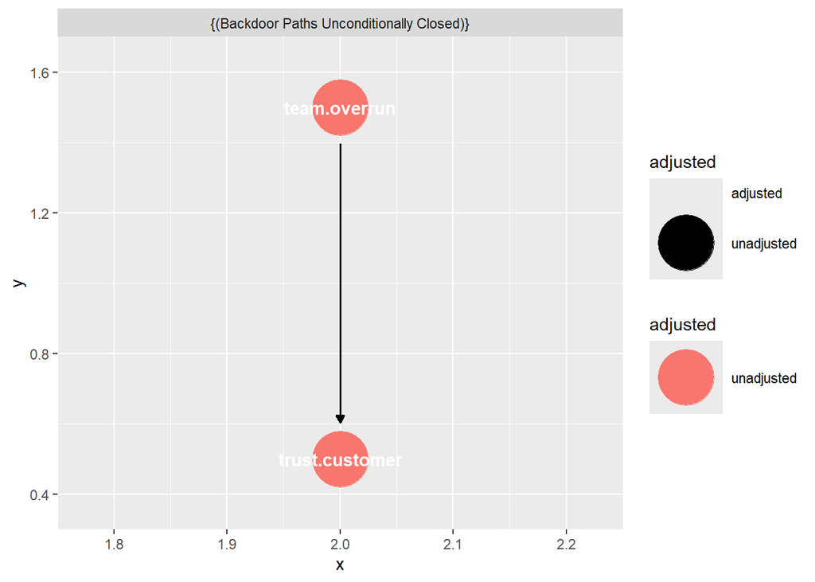

```r
ggdag_adjustment_set(dag, exposure = "team.overrun", outcome = "trust.customer")
```

None of the variables considered in the DAG confound the relationship of interest. This yields the following set of relevant variables:

| Code | Group | Description | Variable |
| --- | --- | --- | --- |
| `team-overrun` | Analysis | The project members collectively agreed that if we don’t start implementation now, we would not finish implementation in time. | `v_566` |
| `trust-customer` | Problems | Lack of trust between our project team members and stakeholder or customer | `v_411` |

## Estimation

In the third step, we quantify the strength of the assumed causal effect. We employ a Bayesian data analysis approach following the guidelines of McElreath[^2] and Gelman et al.[^3]

### Data Preparation

All manual cleaning operations performed on the data are documented in the data cleaning protocol (to be found in data/runs/napire2024/data-cleaning-protocol.md).

```r
d <- load_data(run = "2024", file = "../../data/runs/napire2024/data_cleaned_2024.csv") %>%
  select(v_411, v_566) %>%
  drop_na()

str(d)
```

```
## 'data.frame':    275 obs. of  2 variables:
##  $ v_411: Ord.factor w/ 5 levels "Strongly disagree"<..: 4 3 2 3 4 4 2 4 4 4 ...
##  $ v_566: Ord.factor w/ 5 levels "Strongly disagree"<..: 4 3 2 3 2 3 1 2 2 4 ...
```

Before starting with the analysis, we can visualize the distribution of the data. Ordinal variables are visualized as stacked bars.

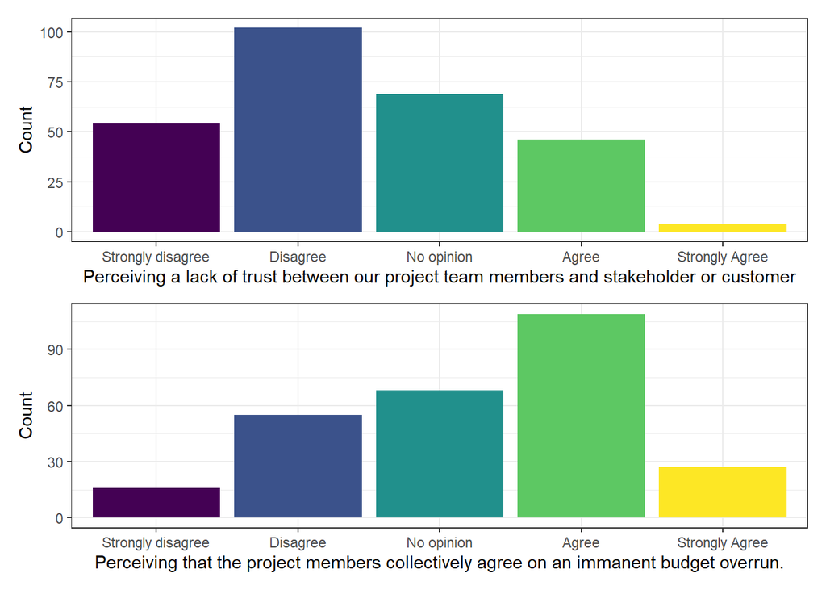

```r
plot.distribution.v411 <- ggplot(d, aes(x = v_411, fill = v_411)) +
    geom_bar() +
    labs(x = "Perceiving a lack of trust between our project team members and stakeholder or customer", y = "Count") +
    theme_bw() +
    guides(fill = "none")

plot.distribution.v566 <- ggplot(d, aes(x = v_566, fill = v_566)) +
    geom_bar() +
    labs(x = "Perceiving that the project members collectively agree on an immanent budget overrun.", y = "Count") +
    theme_bw() +
    guides(fill = "none")

plot.distribution.v411 / plot.distribution.v566
```

### Formula

```r
f1 <- bf(v_411 ~ 1 + v_566)

get_prior(f1, data = d, family = cumulative("probit"))
```

```
##                 prior     class    coef group resp dpar nlpar lb ub
##                (flat)         b
##                (flat)         b v_566.C
##                (flat)         b v_566.L
##                (flat)         b v_566.Q
##                (flat)         b v_566E4
##  student_t(3, 0, 2.5) Intercept
##  student_t(3, 0, 2.5) Intercept       1
##  student_t(3, 0, 2.5) Intercept       2
##  student_t(3, 0, 2.5) Intercept       3
##  student_t(3, 0, 2.5) Intercept       4
##        source
##       default
##  (vectorized)
##  (vectorized)
##  (vectorized)
##  (vectorized)
##       default
##  (vectorized)
##  (vectorized)
##  (vectorized)
##  (vectorized)
```

### Priors

We select uninformative priors for all coefficients, i.e., 0-centered normal distributions with wide variance.

```r
p1 <- c(
  set_prior("normal(0, 1)", class = "Intercept"),
  set_prior("normal(0, 0.5)", class = "b")
)
```

To assess the eligibility of these priors, we perform a prior predictive check. During this check, we sample from the model using the prior probability distributions for each factor coefficient without updating it in light of the data.

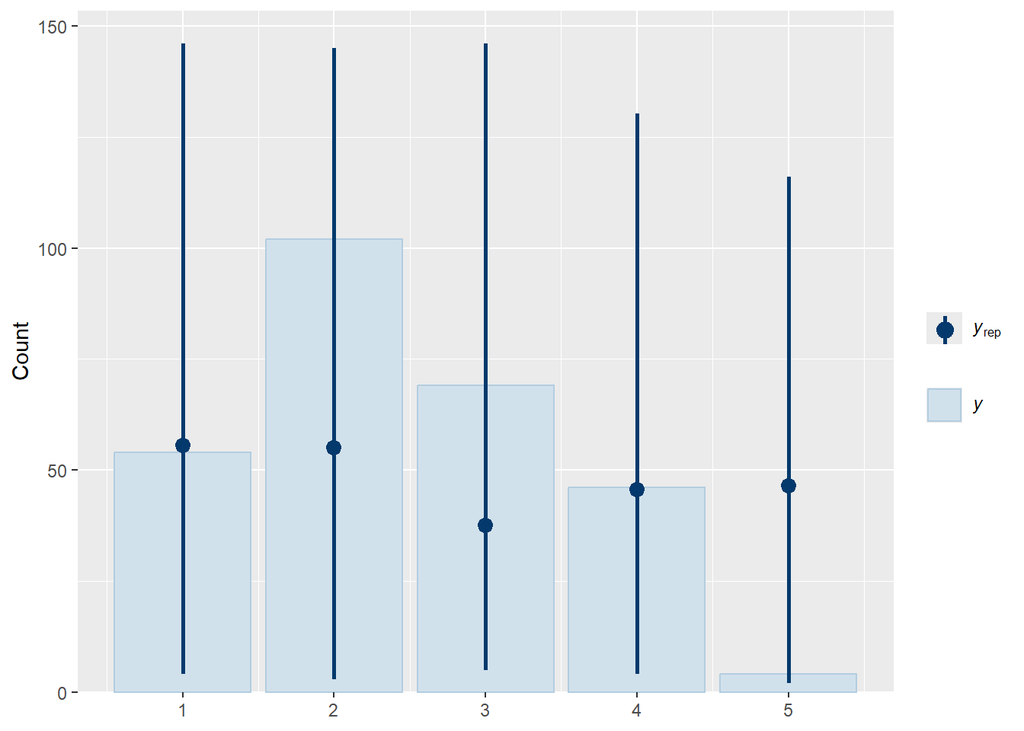

```r
m1.prior <-
  brm(data = d, family = cumulative("probit"), formula = f1, prior = p1,
    iter = 2000, warmup = 1000, chains = 4, cores = 4,
    seed = 4, sample_prior="only",
    file = "../fits/p2h3.prior", file_refit = "on_change"
  )

brms::pp_check(m1.prior, ndraws=100, type = "bars")
```

The sampled prior predictive checks (black whiskers labeled $y_{rep}$) overlap the actually observed data (blue bars labeled $y$), indicating that the selected priors entail the observed reality as realistic.

### Training

With the eligibility of the priors confirmed, we can train the Bayesian regression model, i.e., this time updating the coefficient distributions using Bayes’ theorem.

```r
m1 <-
  brm(data = d, family = cumulative("probit"), formula = f1, prior = p1,
    iter = 2000, warmup = 1000, chains = 4, cores = 4, seed = 4,
    file = "../fits/p2h3", file_refit = "on_change"
  )
```

The training does not mention any diverging chains, which indicates solid sampling. To assess that the model has learned, we perform a posterior predictive check.

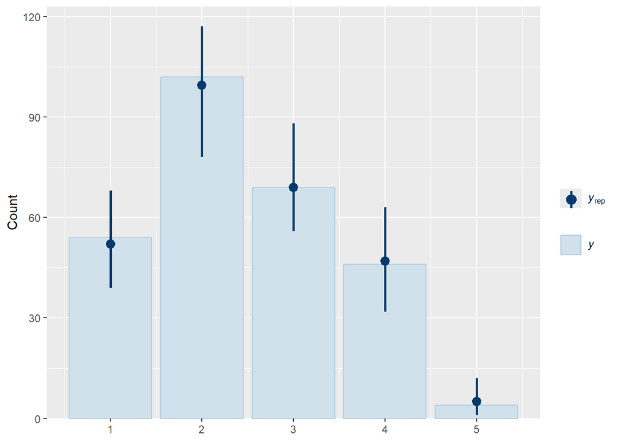

```r
brms::pp_check(m1, ndraws=100, type="bars")
```

The posterior predictions $y_rep$ still overlap the actually observed data $y$ but the whiskers have grown closer to the data, which indicates that the model has learned.

### Evaluation

Finally, we can evaluate the results to answer the initially posed hypothesis.

#### Posterior Distributions

First, we can investigate the raw posterior distributions obtained from the model training. These distributions represent the effect that the respective factor has on the outcome variable. If a distribution is not consistent with 0 (i.e., it does not overlap with 0), then it can be considered statistically significant.

```r
summary(m1)
```

```
##  Family: cumulative
##   Links: mu = probit; disc = identity
## Formula: v_411 ~ 1 + v_566
##    Data: d (Number of observations: 275)
##   Draws: 4 chains, each with iter = 2000; warmup = 1000; thin = 1;
##          total post-warmup draws = 4000
##
## Regression Coefficients:
##              Estimate Est.Error l-95% CI u-95% CI Rhat Bulk_ESS Tail_ESS
## Intercept[1]    -0.79      0.10    -0.98    -0.61 1.00     4085     3185
## Intercept[2]     0.25      0.09     0.07     0.42 1.00     5546     3428
## Intercept[3]     0.99      0.10     0.80     1.18 1.00     5763     3523
## Intercept[4]     2.22      0.19     1.88     2.62 1.00     5176     3045
## v_566.L          0.17      0.20    -0.23     0.56 1.00     4080     3221
## v_566.Q         -0.39      0.18    -0.74    -0.04 1.00     5012     2977
## v_566.C          0.11      0.15    -0.18     0.40 1.00     4328     3322
## v_566E4          0.03      0.13    -0.22     0.28 1.00     5180     2898
##
## Further Distributional Parameters:
##      Estimate Est.Error l-95% CI u-95% CI Rhat Bulk_ESS Tail_ESS
## disc     1.00      0.00     1.00     1.00   NA       NA       NA
##
## Draws were sampled using sampling(NUTS). For each parameter, Bulk_ESS
## and Tail_ESS are effective sample size measures, and Rhat is the potential
## scale reduction factor on split chains (at convergence, Rhat = 1).
```

These distributions are, however, difficult to interpret, because they are in the parameter space (i.e., on a probit scale), not the outcome space. To investigate the effects on the outcome space (i.e., in terms of how they affect the likelihood to select a certain category of the Likert-scale), we need to assess the marginal effects.

#### Marginal Effects

To visualize the effect of the predictors on the outcome variable, we plot the marginal effects. Marginal effects isolate the effect of one predictor while keeping all other predictors at a representative level. The main effect of interest is whether perceiving an immanent budget overrun in the team (`v_566`) impacts the agreement to the statement that there is a lack of trust between the team and stakeholders/customers (`v_411`). In the resulting plot, each dot and overlapping whisker represents the mean value and the credibility interval for the probability (y-axis) that a survey participant agreeing to perceiving an immanent budget overrun in the team (x-axis) would give a certain response (color) to the question “How much do you agree or disagree with the following statements about your project: Lack of trust between our project team members and stakeholder or customer.”

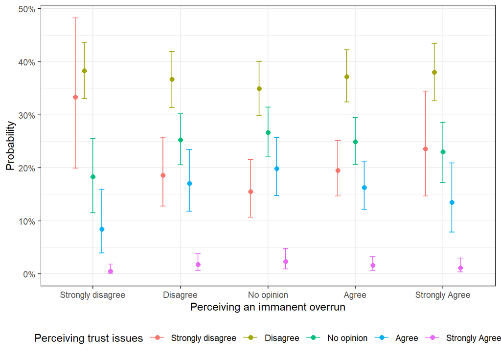

```r
conditional_effects(m1, "v_566", categorical = TRUE, prob = 0.89)[[1]] %>%
  ggplot(aes(x = v_566, color = cats__)) +
    geom_point(aes(y = estimate__), size = 2, position = position_dodge(width = 0.5)) +
    geom_errorbar(aes(ymin = lower__, ymax = upper__), width = 0.3, position = position_dodge(width = 0.5)) +
    labs(x = "Perceiving an immanent overrun", y = "Probability", color = "Perceiving trust issues") +
    scale_y_continuous(labels = scales::percent) +
    theme_bw() +
    theme(legend.position = "bottom")
```

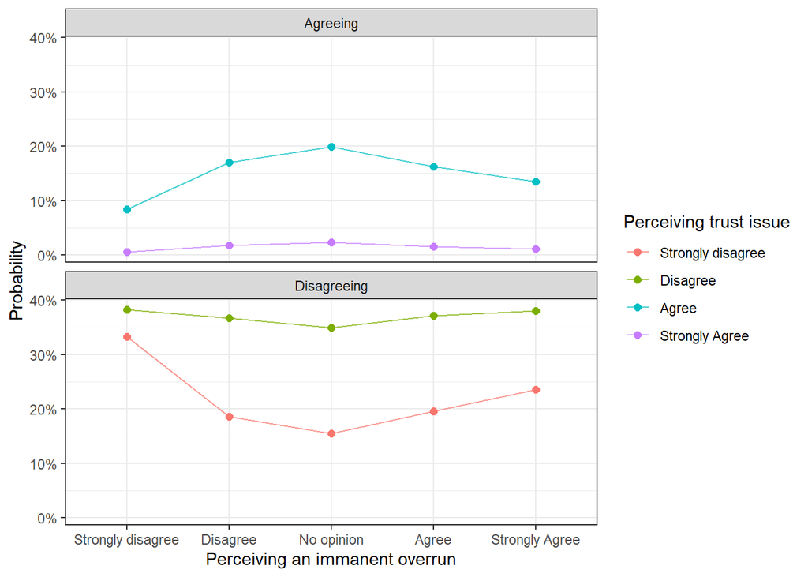

```r
conditional_effects(m1, "v_566", categorical = TRUE, prob = 0.89)[[1]] %>%
  filter(cats__ != "No opinion") %>%
  mutate(agree = ifelse(cats__ %in% c("Strongly Agree", "Agree"), "Agreeing", "Disagreeing")) %>%
  ggplot(aes(x = v_566, color = cats__)) +
    geom_point(aes(y = estimate__), size = 2) +
    geom_line(aes(y = estimate__, group = cats__), alpha = 0.7) +
    labs(x = "Perceiving an immanent overrun", y = "Probability", color = "Perceiving trust issue") +
    scale_y_continuous(labels = scales::percent) +
    facet_wrap(~agree, ncol = 1) +
    theme_bw()
```

Note that this plot connects the dots (i.e., the average probability per frequency) with lines, which is mathematically incorrect, as the x-axis is ordinal (i.e., categorical) and there is no continuum between two levels. The connecting lines are solely to visualize the trend better.

## Conclusion

The obtained results invite the following conclusion. Both respondents that agree and disagree, but less so respondents that are undecided, to their team perceiving an immanent budget overrun, rather disagree than agree with a lack of trust between the project team and their members. However, there is a slight tendency towards one direction: when *not* perceiving an immanent budget overrun, the probability of reporting trust issues is lowest. This follows the intuition that problems in the team are projected outwards to the customer.

[^1]: Siebert, J. (2023). Applications of statistical causal inference in software engineering. Information and Software Technology, 159, 107198.
[^2]: McElreath, R. (2018). Statistical rethinking: A Bayesian course with examples in R and Stan. Chapman and Hall/CRC.
[^3]: Gelman, A., Carlin, J. B., Stern, H. S., & Rubin, D. B. (1995). Bayesian data analysis. Chapman and Hall/CRC.